RAGHVENDRA SINGH SHAKTAWAT FINAL PROJECT

```r
#Using the required libraries
library(mlbench)
library(tidyverse)
library(tidyr)
library(stringr)
library(klaR)
library(psych)
library(forcats)
library(caret)
```

```r
library(corrplot)
#uploading the dataset
google_drive_link <- "https://drive.google.com/uc?id=1ndw7a5uzu97iudi21grW7NiovLcc7re1&export=download"
pizza <- read.csv(file = google_drive_link, header = TRUE)
head(pizza)
```

```
##   brand    id  mois  prot   fat  ash sodium carb  cal
## 1     A 14069 27.82 21.43 44.87 5.11   1.77 0.77 4.93
## 2     A 14053 28.49 21.26 43.89 5.34   1.79 1.02 4.84
## 3     A 14025 28.35 19.99 45.78 5.08   1.63 0.80 4.95
## 4     A 14016 30.55 20.15 43.13 4.79   1.61 1.38 4.74
## 5     A 14005 30.49 21.28 41.65 4.82   1.64 1.76 4.67
## 6     A 14075 31.14 20.23 42.31 4.92   1.65 1.40 4.67
```

```r
dim(pizza)
```

```
## [1] 300   9
```

The aim of this project is to predict the calories of pizza. After loading all the relevant libraries along with some additional ones, I loaded the data set and named the data frame as pizza.

This data set consists of the components of Pizza which makes it healthy in which there are 300 rows and 9 columns present.

Following are the names of the 9 columns that are present in this data set:

```r
#Names of different columns present in the data set.
colnames(pizza)
```

```
## [1] "brand"  "id"     "mois"   "prot"   "fat"    "ash"    "sodium" "carb"
## [9] "cal"
```

```r
#glimpse of the dataset
glimpse(pizza)
```

```
## Rows: 300
## Columns: 9
## $ brand  <chr> "A", "A", "A", "A", "A", "A", "A", "A", "A", "A", "A", "A", "A"~
## $ id     <int> 14069, 14053, 14025, 14016, 14005, 14075, 14082, 14097, 14117, ~
## $ mois   <dbl> 27.82, 28.49, 28.35, 30.55, 30.49, 31.14, 31.21, 28.76, 28.22, ~
## $ prot   <dbl> 21.43, 21.26, 19.99, 20.15, 21.28, 20.23, 20.97, 21.41, 20.48, ~
## $ fat    <dbl> 44.87, 43.89, 45.78, 43.13, 41.65, 42.31, 41.34, 41.60, 45.10, ~
## $ ash    <dbl> 5.11, 5.34, 5.08, 4.79, 4.82, 4.92, 4.71, 5.28, 5.02, 5.16, 4.9~
## $ sodium <dbl> 1.77, 1.79, 1.63, 1.61, 1.64, 1.65, 1.58, 1.75, 1.71, 1.66, 1.6~
## $ carb   <dbl> 0.77, 1.02, 0.80, 1.38, 1.76, 1.40, 1.77, 2.95, 1.18, 0.64, 0.9~
## $ cal    <dbl> 4.93, 4.84, 4.95, 4.74, 4.67, 4.67, 4.63, 4.72, 4.93, 4.95, 4.9~
```

When looking at the glimpse of the data set, there are multiple categories that are present in a particular column. For example, the brand column has ten different brands which ranges from A-J. There are different columns that indicate the amount of water, protein, fats, ash, sodium content, carbohydrates, and calories per hundred grams in the sample.

```r
#checking for the NA values
any(is.na(pizza))
```

```
## [1] FALSE
```

```r
#Missing values in data
colSums(is.na(pizza))
```

```
##  brand     id   mois   prot    fat    ash sodium   carb    cal
##      0      0      0      0      0      0      0      0      0
```

```r
#Looking at the structure of the dataset
str(pizza)
```

```
## 'data.frame':    300 obs. of  9 variables:
##  $ brand : chr  "A" "A" "A" "A" ...
##  $ id    : int  14069 14053 14025 14016 14005 14075 14082 14097 14117 14133 ...
##  $ mois  : num  27.8 28.5 28.4 30.6 30.5 ...
##  $ prot  : num  21.4 21.3 20 20.1 21.3 ...
##  $ fat   : num  44.9 43.9 45.8 43.1 41.6 ...
##  $ ash   : num  5.11 5.34 5.08 4.79 4.82 4.92 4.71 5.28 5.02 5.16 ...
##  $ sodium: num  1.77 1.79 1.63 1.61 1.64 1.65 1.58 1.75 1.71 1.66 ...
##  $ carb  : num  0.77 1.02 0.8 1.38 1.76 1.4 1.77 2.95 1.18 0.64 ...
##  $ cal   : num  4.93 4.84 4.95 4.74 4.67 4.67 4.63 4.72 4.93 4.95 ...
```

Looking at the structure of the pizza data frame, there is one column of characters and integers and majority of the columns possess numerical values.

```r
#counting the numbers per brand of pizza
pizza %>% count(brand)
```

```
##    brand  n
## 1      A 29
## 2      B 31
## 3      C 27
## 4      D 32
## 5      E 28
## 6      F 30
## 7      G 29
## 8      H 33
## 9      I 29
## 10     J 32
```

In the above R chunk, the total count of that column which has multiple features is mentioned and it is represented in the form of bar chart below.

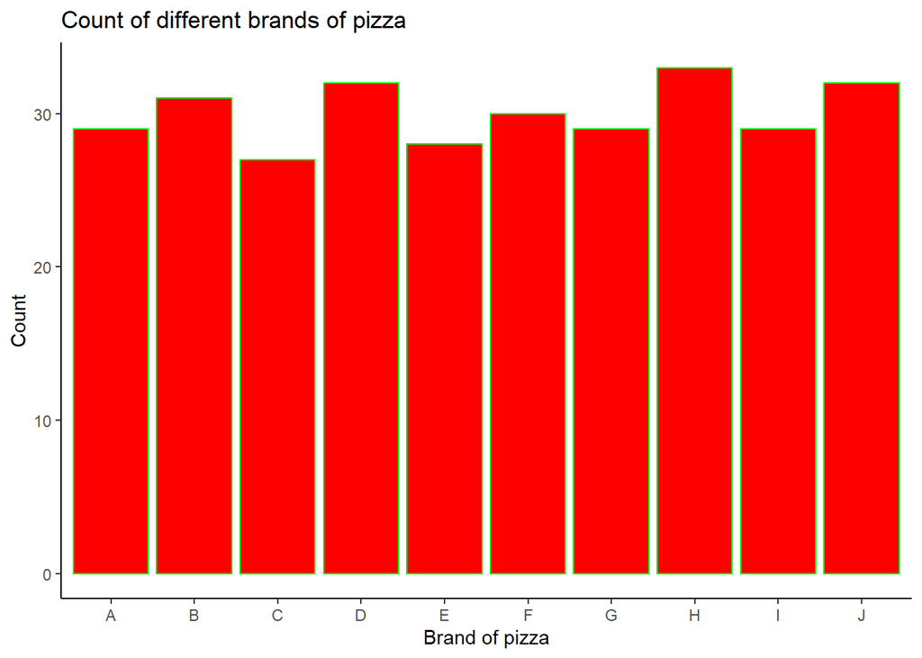

```r
#counting different brands of pizza through histogram
ggplot(pizza, aes(brand)) + geom_bar(fill = "red", color = "green") + labs(x = "Brand of pizza", y = "Count") + ggtitle("Count of different brands of pizza") + theme_classic()
```

In the bar chart of the pizza brand, there are ten codes and their total count is represented. From the visualization, it is clearly visible that H has the maximum count of 33. The second highest count is of the brands D and J, both at 32 and the minimum count is of the brand C at 27.

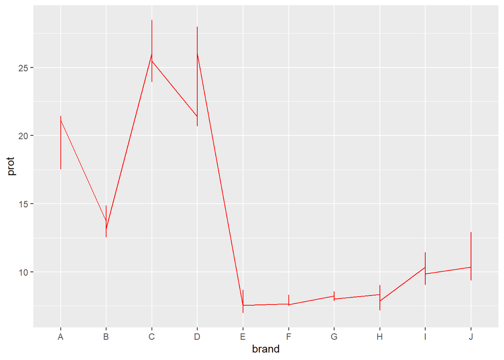

```r
#plotting the relationship between brand of pizza and protein content
ggplot(pizza, aes(brand, prot)) + geom_line(col = "red",group = 1)
```

The line chart represents the relationship between brand of pizza and protein content and it is clearly evident that pizza of brand C has the maximum protein content.

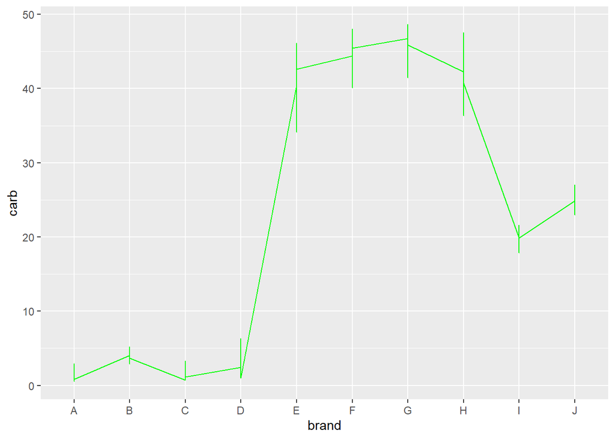

```r
#plotting the relationship between brand of pizza and carbohydrates
ggplot(pizza, aes(brand, carb)) + geom_line(col = "green", group = 1)
```

```r
#assigning a new data frame name
pizza_new <- pizza
```

```r
#putting NA values in the new data frame
pizza_new$prot[c(19.99, 21.26, 20.23, 18.05, 13.70, 12.93, 26.00, 7.54)] <- NA
pizza_new$fat[c(42.31, 45.59, 21.39, 21.01, 42.29, 17.37, 16.41, 18)] <- NA
pizza_new$ash[c(5.34, 5.02, 5.15, 3.55, 3.57, 3.02, 4.66, 1.31, 1.35)] <- NA
pizza_new$sodium[c(.72, 1.77, 1.64, 1.65, 1.06, .98, .41, .72, .44)] <- NA
head(pizza_new)
```

```
##   brand    id  mois  prot   fat  ash sodium carb  cal
## 1     A 14069 27.82 21.43 44.87   NA     NA 0.77 4.93
## 2     A 14053 28.49 21.26 43.89 5.34   1.79 1.02 4.84
## 3     A 14025 28.35 19.99 45.78   NA   1.63 0.80 4.95
## 4     A 14016 30.55 20.15 43.13   NA   1.61 1.38 4.74
## 5     A 14005 30.49 21.28 41.65   NA   1.64 1.76 4.67
## 6     A 14075 31.14 20.23 42.31 4.92   1.65 1.40 4.67
```

Since there are no NA values present in the original data frame, I decided to insert some NA values into a new data frame so that I can perform mean imputation below.

```r
#Imputation of multiple columns (i.e. the whole data frame) using mean
for(i in 1:ncol(pizza_new)) {
  pizza_new[ , i][is.na(pizza_new[ , i])] <- mean(pizza_new[ , i], na.rm = TRUE)
}
head(pizza_new)
```

```
##   brand    id  mois  prot   fat      ash    sodium carb  cal
## 1     A 14069 27.82 21.43 44.87 2.601926 0.6657191 0.77 4.93
## 2     A 14053 28.49 21.26 43.89 5.340000 1.7900000 1.02 4.84
## 3     A 14025 28.35 19.99 45.78 2.601926 1.6300000 0.80 4.95
## 4     A 14016 30.55 20.15 43.13 2.601926 1.6100000 1.38 4.74
## 5     A 14005 30.49 21.28 41.65 2.601926 1.6400000 1.76 4.67
## 6     A 14075 31.14 20.23 42.31 4.920000 1.6500000 1.40 4.67
```

Now, I am going to perform the hot-encoding for all the different brands of pizza present in the dataset.

```r
table(pizza_new[pizza_new$brand == "A", "brand"])
```

```
##
##  A
## 29
```

```r
#performing hot-encoding for brands A and B
pizza_new$brand_AB <- ifelse(pizza_new$brand == "A", 1, ifelse(pizza_new$brand == "B", 1, 0))
```

```r
table(pizza_new$brand_AB)
```

```
##
##   0   1
## 240  60
```

```r
#performing hot-encoding for brands C and D
pizza_new$brand_CD <- ifelse(pizza_new$brand == "C", 1, ifelse(pizza_new$brand == "D", 1, 0))
```

```r
table(pizza_new$brand_CD)
```

```
##
##   0   1
## 241  59
```

```r
#performing hot-encoding for brands E and F
pizza_new$brand_EF <- ifelse(pizza_new$brand == "E", 1, ifelse(pizza_new$brand == "F", 1, 0))
```

```r
table(pizza_new$brand_EF)
```

```
##
##   0   1
## 242  58
```

```r
#performing hot-encoding for brands G and H
pizza_new$brand_GH <- ifelse(pizza_new$brand == "G", 1, ifelse(pizza_new$brand == "H", 1, 0))
```

```r
table(pizza_new$brand_GH)
```

```
##
##   0   1
## 238  62
```

```r
#performing hot-encoding for brands I and J
pizza_new$brand_IJ <- ifelse(pizza_new$brand == "I", 1, ifelse(pizza_new$brand == "J", 1, 0))
```

```r
table(pizza_new$brand_IJ)
```

```
##
##   0   1
## 239  61
```

```r
head(pizza_new)
```

```
##   brand    id  mois  prot   fat      ash    sodium carb  cal brand_AB brand_CD
## 1     A 14069 27.82 21.43 44.87 2.601926 0.6657191 0.77 4.93        1        0
## 2     A 14053 28.49 21.26 43.89 5.340000 1.7900000 1.02 4.84        1        0
## 3     A 14025 28.35 19.99 45.78 2.601926 1.6300000 0.80 4.95        1        0
## 4     A 14016 30.55 20.15 43.13 2.601926 1.6100000 1.38 4.74        1        0
## 5     A 14005 30.49 21.28 41.65 2.601926 1.6400000 1.76 4.67        1        0
## 6     A 14075 31.14 20.23 42.31 4.920000 1.6500000 1.40 4.67        1        0
##   brand_EF brand_GH brand_IJ
## 1        0        0        0
## 2        0        0        0
## 3        0        0        0
## 4        0        0        0
## 5        0        0        0
## 6        0        0        0
```

```r
#converting the character and integer column to numeric
pizza[,1] <- as.numeric(factor(pizza[,1]))
pizza[,2] <- as.numeric(pizza[,2])
```

```r
#converting the character and integer column to numeric for the hot-encoded data set
pizza_new[,1] <- as.numeric(factor(pizza_new[,1]))
pizza_new[,2] <- as.numeric(pizza_new[,2])
```

For indicating the initial overview of the data and to show different groups of data with different colors I am going to use pairs.panels by using the Psych package. Here, each individual plot is going to show the relationship between the variables in the horizontal and vertical grid.

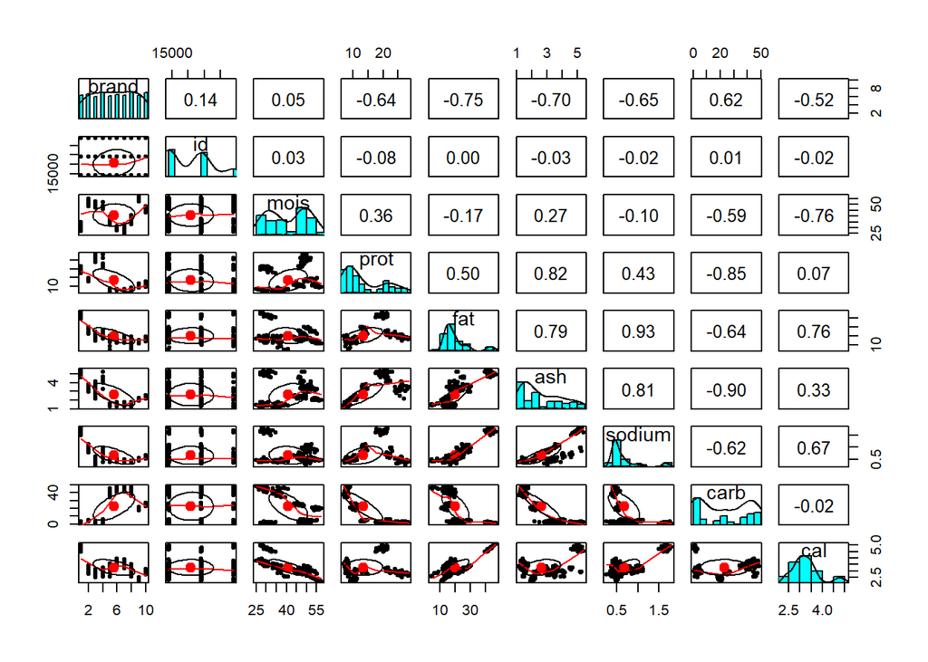

```r
#visualizing the distribution of data
pairs.panels(pizza)
```

I installed the KLAR package and used pairs.panel to visualize the distribution of the numeric features that are present in the data set.

For checking the normality of each column, I used the Shapiro-Wilk normality test.

```r
#checking the normality of each column
shapiro.test(pizza$mois)
```

```
##
##  Shapiro-Wilk normality test
##
## data:  pizza$mois
## W = 0.90018, p-value = 3.583e-13
```

```r
shapiro.test(pizza$prot)
```

```
##
##  Shapiro-Wilk normality test
##
## data:  pizza$prot
## W = 0.81522, p-value < 2.2e-16
```

```r
shapiro.test(pizza$fat)
```

```
##
##  Shapiro-Wilk normality test
##
## data:  pizza$fat
## W = 0.80468, p-value < 2.2e-16
```

```r
shapiro.test(pizza$ash)
```

```
##
##  Shapiro-Wilk normality test
##
## data:  pizza$ash
## W = 0.86743, p-value = 2.213e-15
```

```r
shapiro.test(pizza$sodium)
```

```
##
##  Shapiro-Wilk normality test
##
## data:  pizza$sodium
## W = 0.7099, p-value < 2.2e-16
```

```r
shapiro.test(pizza$carb)
```

```
##
##  Shapiro-Wilk normality test
##
## data:  pizza$carb
## W = 0.84116, p-value < 2.2e-16
```

```r
shapiro.test(pizza$cal)
```

```
##
##  Shapiro-Wilk normality test
##
## data:  pizza$cal
## W = 0.90354, p-value = 6.434e-13
```

```r
#finding the correlation between the columns of data set
correlation_records <- cor(pizza[c("mois","prot","fat","ash","sodium","carb","cal")],method = "pearson",use = "complete.obs")
correlation_records
```

```
##              mois       prot        fat        ash     sodium        carb
## mois    1.0000000  0.3602477 -0.1713182  0.2655555 -0.1022789 -0.59180165
## prot    0.3602477  1.0000000  0.4980017  0.8238437  0.4291295 -0.85354226
## fat    -0.1713182  0.4980017  1.0000000  0.7916340  0.9333252 -0.64023817
## ash     0.2655555  0.8238437  0.7916340  1.0000000  0.8081221 -0.89898837
## sodium -0.1022789  0.4291295  0.9333252  0.8081221  1.0000000 -0.62017634
## carb   -0.5918017 -0.8535423 -0.6402382 -0.8989884 -0.6201763  1.00000000
## cal    -0.7644405  0.0702581  0.7645671  0.3264685  0.6719575 -0.02348458
##                cal
## mois   -0.76444054
## prot    0.07025810
## fat     0.76456710
## ash     0.32646845
## sodium  0.67195750
## carb   -0.02348458
## cal     1.00000000
```

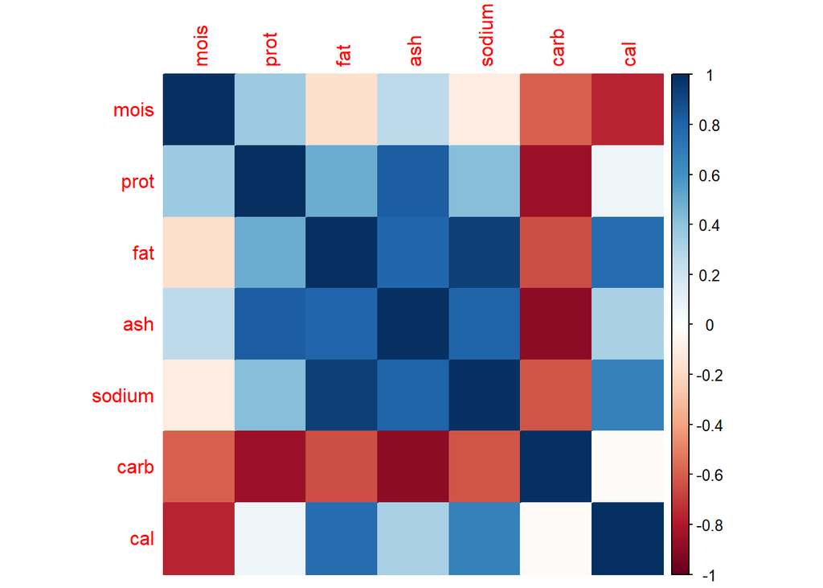

```r
#plotting the correlations
corrplot(correlation_records, method="color")
```

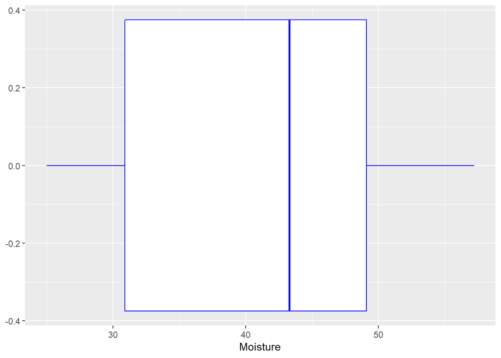

```r
#checking the outliers for moisture column
ggplot(pizza, aes(mois)) + geom_boxplot(outlier.colour = "red", color = "blue") + labs(x = "Moisture")
```

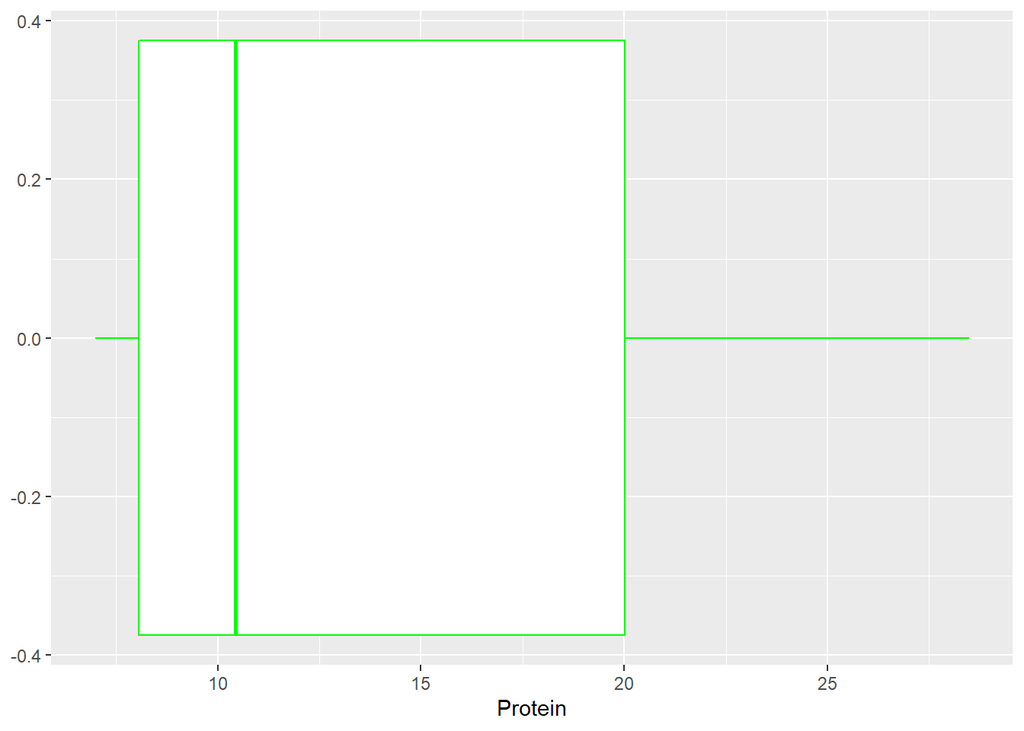

```r
#checking the outliers for protein column
ggplot(pizza, aes(prot)) + geom_boxplot(outlier.colour = "red", color = "green") + labs(x = "Protein")
```

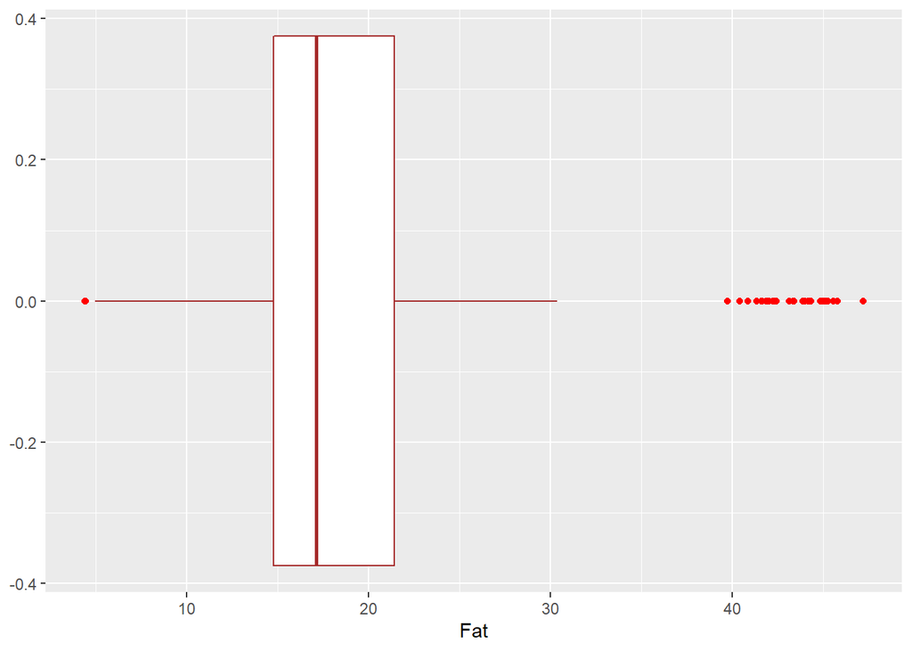

```r
#checking the outliers for fat column
ggplot(pizza, aes(fat)) + geom_boxplot(outlier.colour = "red", color = "brown") + labs(x = "Fat")
```

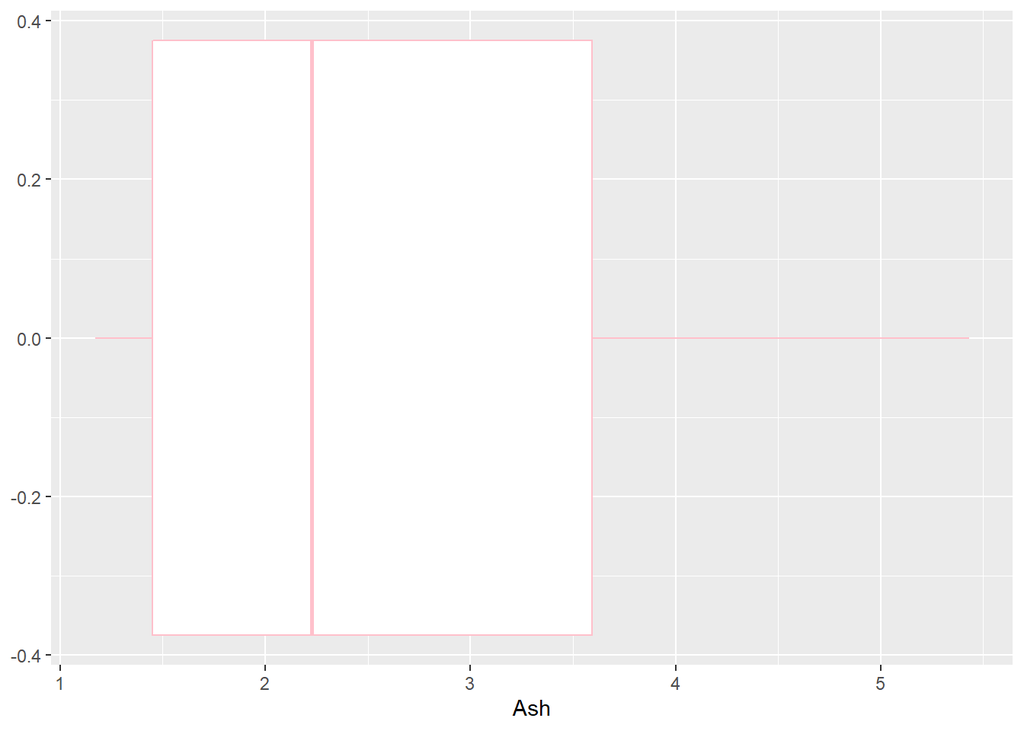

```r
#checking the outliers for ash column
ggplot(pizza, aes(ash)) + geom_boxplot(outlier.colour = "red", color = "pink") + labs(x = "Ash")
```

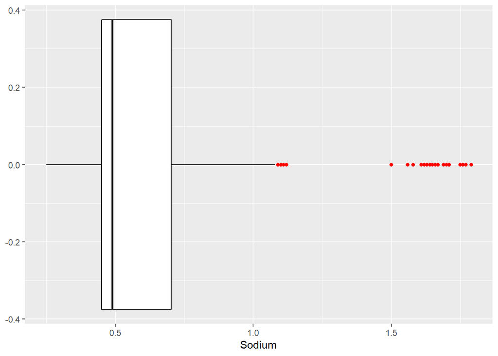

```r
#checking the outliers for sodium column
ggplot(pizza, aes(sodium)) + geom_boxplot(outlier.colour = "red", color = "black") + labs(x = "Sodium")
```

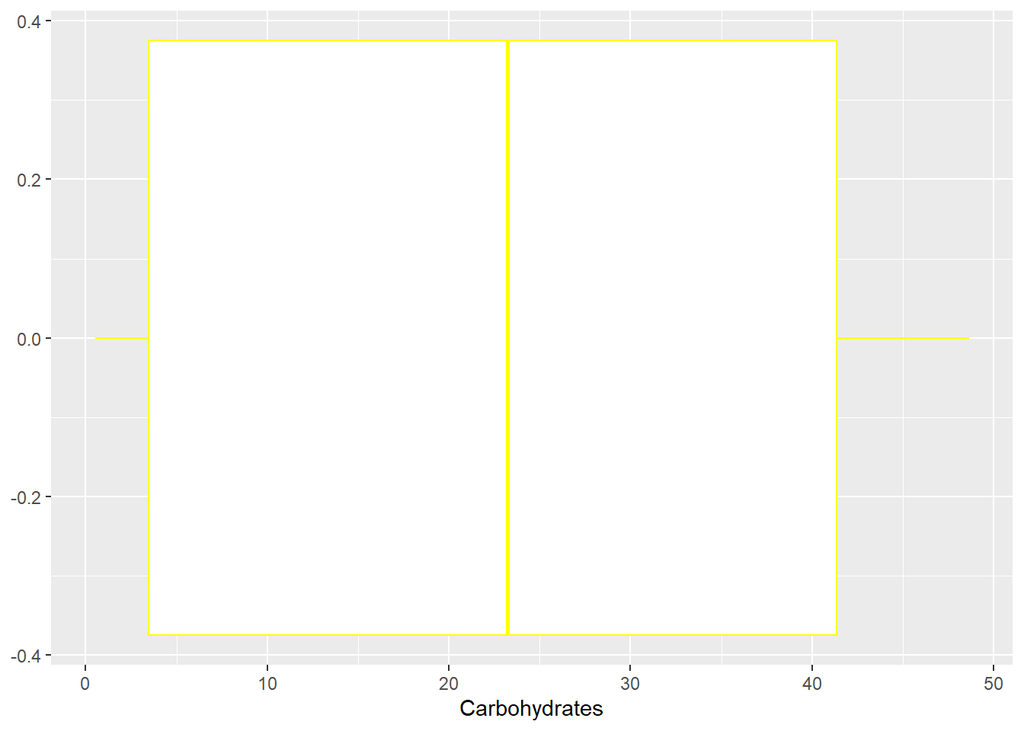

```r
#checking the outliers for carbohydrates column
ggplot(pizza, aes(carb)) + geom_boxplot(outlier.colour = "orange", color = "yellow") + labs(x = "Carbohydrates")
```

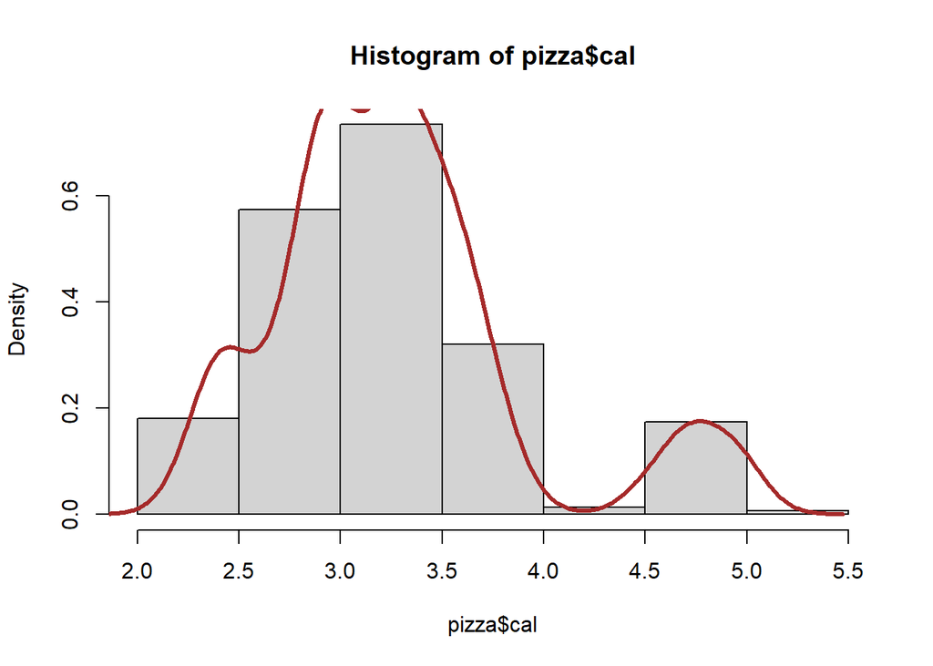

```r
hist(pizza$cal, probability = TRUE)
lines(density(pizza$cal), col = "brown", lwd = 3)
```

I am also going to visualize how every column of the pizza dataset looks at this point through a univariate visualization which shows histograms of each attribute below.

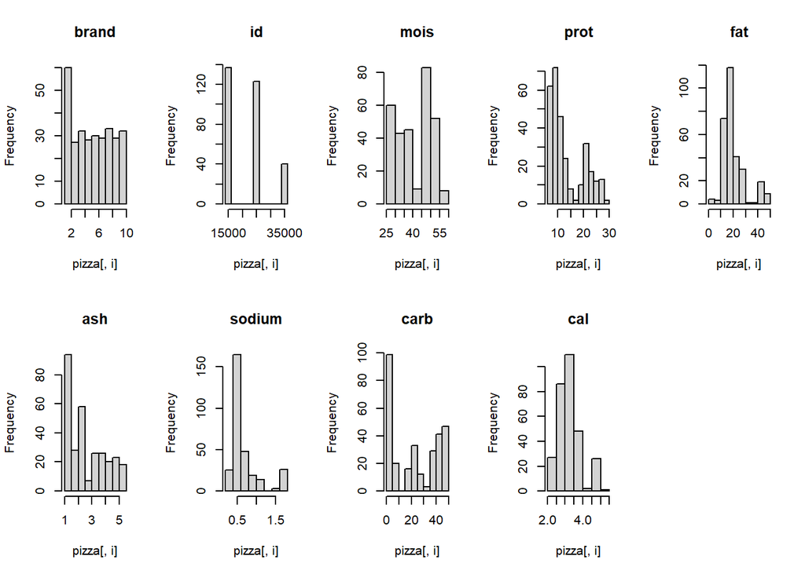

```r
#histograms each attribute
par(mfrow=c(2,5))
for(i in 1:9) {
  hist(pizza[,i], main=names(pizza)[i])
}
```

Following are the density plots for each attribute.

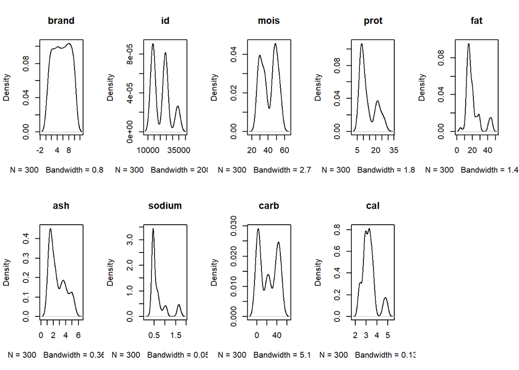

```r
#density plots each attribute
par(mfrow=c(2,5))
for(i in 1:9) {
  plot(density(pizza[,i]), main=names(pizza)[i])
}
```

I also created boxplots of each attribute.

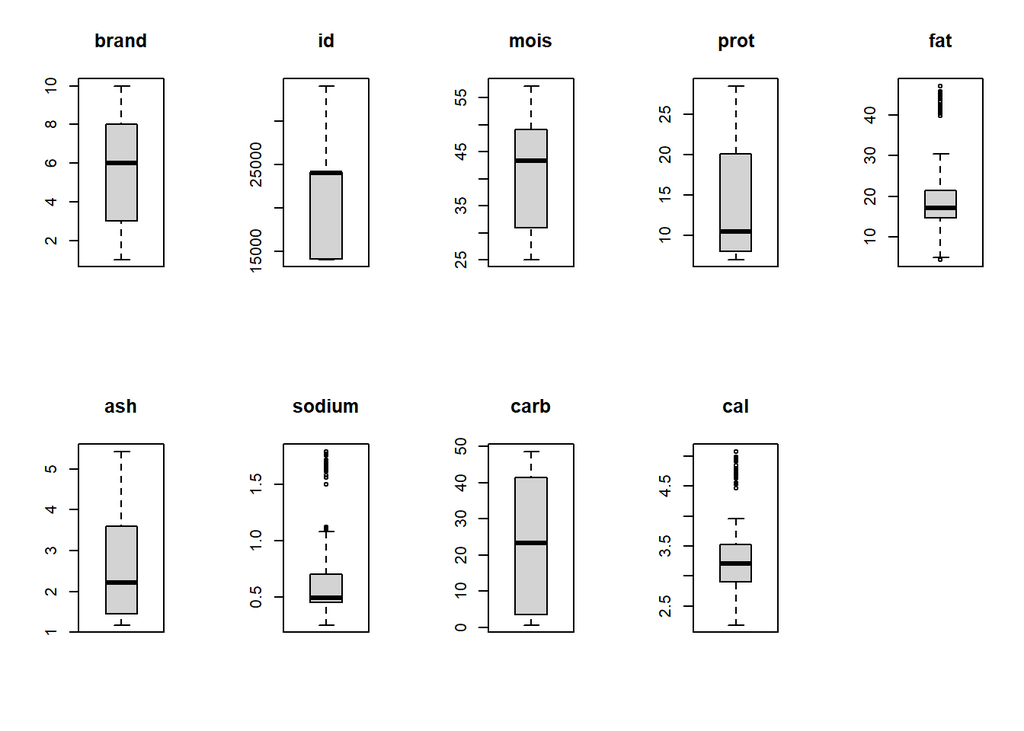

```r
#boxplots each attribute
par(mfrow=c(2,5))
for(i in 1:9) {
  boxplot(pizza[,i], main=names(pizza)[i])
}
```

```r
#performing the z score standardization
Zscore <- function(column) {
    z <- abs((mean(column) - column) / sd(column))
}
```

```r
columns <- c("mois","prot","fat","ash","sodium","carb","cal")
```

```r
for (column in columns) {
    z <- Zscore(pizza_new[[column]])
    pizza_new[[paste('z.score.', column, sep = '')]] = z}
head(pizza_new)
```

```
##   brand    id  mois  prot   fat      ash    sodium carb  cal brand_AB brand_CD
## 1     1 14069 27.82 21.43 44.87 2.601926 0.6657191 0.77 4.93        1        0
## 2     1 14053 28.49 21.26 43.89 5.340000 1.7900000 1.02 4.84        1        0
## 3     1 14025 28.35 19.99 45.78 2.601926 1.6300000 0.80 4.95        1        0
## 4     1 14016 30.55 20.15 43.13 2.601926 1.6100000 1.38 4.74        1        0
## 5     1 14005 30.49 21.28 41.65 2.601926 1.6400000 1.76 4.67        1        0
## 6     1 14075 31.14 20.23 42.31 4.920000 1.6500000 1.40 4.67        1        0
##   brand_EF brand_GH brand_IJ z.score.mois z.score.prot z.score.fat z.score.ash
## 1        0        0        0     1.369526     1.297923    2.919866    0.000000
## 2        0        0        0     1.299391     1.271121    2.805319    2.207021
## 3        0        0        0     1.314046     1.070899    3.026231    0.000000
## 4        0        0        0     1.083752     1.096124    2.716486    0.000000
## 5        0        0        0     1.090033     1.274275    2.543497    0.000000
## 6        0        0        0     1.021991     1.108736    2.620641    1.868480
##   z.score.sodium z.score.carb z.score.cal
## 1       0.000000     1.225463    2.675659
## 2       3.081667     1.211598    2.530505
## 3       2.643105     1.223800    2.707915
## 4       2.588285     1.191630    2.369224
## 5       2.670515     1.170554    2.256327
## 6       2.697925     1.190521    2.256327
```

In order to adjust the scales of features, I performed a data preprocessing step known as normalization. Thus, after performing normalization of the columns present in the pizza data frame, the statistical distribution of the data got affected. I used the minimum-maximum scaling method to normalize the values where the data values have a range from 0 to 1. Because of this, the effect of outliers on the values of data gets suppressed to a certain extent and the smaller values of the standard deviation of data gets scaled. After performing normalization, the data set is presented as below.

```r
#Normalization of the data
min_max_norm <- function(x) {
    (x - min(x)) / (max(x) - min(x))
}
pizza_norm <- as.data.frame(lapply(pizza_new[c(3:8)], min_max_norm))
```

```r
head(pizza_norm)
```

```
##         mois      prot       fat       ash    sodium        carb
## 1 0.08752328 0.6720930 0.9780193 0.3361328 0.2699474 0.005402036
## 2 0.10831782 0.6641860 0.9543478 0.9788732 1.0000000 0.010596302
## 3 0.10397269 0.6051163 1.0000000 0.3361328 0.8961039 0.006025348
## 4 0.17225326 0.6125581 0.9359903 0.3361328 0.8831169 0.018076044
## 5 0.17039106 0.6651163 0.9002415 0.3361328 0.9025974 0.025971328
## 6 0.19056487 0.6162791 0.9161836 0.8802817 0.9090909 0.018491585
```

So, in the above R chunk, I performed the normalization of data i.e., minimum-maximum normalization.

```r
#Log transformation of data
log_mois <- log1p(pizza_new$mois)
log_prot <- log1p(pizza_new$prot)
log_fat <- log1p(pizza_new$fat)
log_ash <- log1p(pizza_new$ash)
log_sodium <- log1p(pizza_new$sodium)
log_carb <- log1p(pizza_new$carb)
log_cal <- log1p(pizza_new$cal)
```

From visualizations, as well as statistics, data did not look normal. Therefore I performed log transformation of data.

```r
# Combining the transformed variables
pizza_transformed <- data.frame(log_mois, log_prot, log_fat, log_ash, log_sodium, log_carb, log_cal)
head(pizza_transformed)
```

```
##   log_mois log_prot  log_fat  log_ash log_sodium  log_carb  log_cal
## 1 3.361070 3.110399 3.825811 1.281469  0.5102569 0.5709795 1.780024
## 2 3.384051 3.102791 3.804215 1.846879  1.0260416 0.7030975 1.764731
## 3 3.379293 3.044046 3.845456 1.281469  0.9669838 0.5877867 1.783391
## 4 3.451574 3.051640 3.787140 1.281469  0.9593502 0.8671005 1.747459
## 5 3.449670 3.103689 3.753027 1.281469  0.9707789 1.0152307 1.735189
## 6 3.470101 3.055415 3.768384 1.778336  0.9745596 0.8754687 1.735189
```

```r
#joining the two data frames
pizza_join <- cbind(pizza_new, pizza_transformed)
head(pizza_join)
```

```
##   brand    id  mois  prot   fat      ash    sodium carb  cal brand_AB brand_CD
## 1     1 14069 27.82 21.43 44.87 2.601926 0.6657191 0.77 4.93        1        0
## 2     1 14053 28.49 21.26 43.89 5.340000 1.7900000 1.02 4.84        1        0
## 3     1 14025 28.35 19.99 45.78 2.601926 1.6300000 0.80 4.95        1        0
## 4     1 14016 30.55 20.15 43.13 2.601926 1.6100000 1.38 4.74        1        0
## 5     1 14005 30.49 21.28 41.65 2.601926 1.6400000 1.76 4.67        1        0
## 6     1 14075 31.14 20.23 42.31 4.920000 1.6500000 1.40 4.67        1        0
##   brand_EF brand_GH brand_IJ z.score.mois z.score.prot z.score.fat z.score.ash
## 1        0        0        0     1.369526     1.297923    2.919866    0.000000
## 2        0        0        0     1.299391     1.271121    2.805319    2.207021
## 3        0        0        0     1.314046     1.070899    3.026231    0.000000
## 4        0        0        0     1.083752     1.096124    2.716486    0.000000
## 5        0        0        0     1.090033     1.274275    2.543497    0.000000
## 6        0        0        0     1.021991     1.108736    2.620641    1.868480
##   z.score.sodium z.score.carb z.score.cal log_mois log_prot  log_fat  log_ash
## 1       0.000000     1.225463    2.675659 3.361070 3.110399 3.825811 1.281469
## 2       3.081667     1.211598    2.530505 3.384051 3.102791 3.804215 1.846879
## 3       2.643105     1.223800    2.707915 3.379293 3.044046 3.845456 1.281469
## 4       2.588285     1.191630    2.369224 3.451574 3.051640 3.787140 1.281469
## 5       2.670515     1.170554    2.256327 3.449670 3.103689 3.753027 1.281469
## 6       2.697925     1.190521    2.256327 3.470101 3.055415 3.768384 1.778336
##   log_sodium  log_carb  log_cal
## 1  0.5102569 0.5709795 1.780024
## 2  1.0260416 0.7030975 1.764731
## 3  0.9669838 0.5877867 1.783391
## 4  0.9593502 0.8671005 1.747459
## 5  0.9707789 1.0152307 1.735189
## 6  0.9745596 0.8754687 1.735189
```

```r
#using dummy variable for calorie column
pizza_new$cal <- ifelse(pizza_new$cal > "3", 0, 1)
```

```r
#joining the two data frames
new_pizza <- cbind(pizza_new, pizza_norm)
```

```r
#selecting the appropriate columns
pizza_df <- subset(new_pizza, select = c(1,22,23,24,25,26,27,9))
```

```r
#Performing the principal component analysis
pizza_pca <- prcomp(pizza_df[c(1,2,3,4,5,6,7)], center = TRUE,scale. = TRUE)
summary(pizza_pca)
```

```
## Importance of components:
##                           PC1    PC2     PC3     PC4     PC5     PC6     PC7
## Standard deviation     2.1096 1.2466 0.72085 0.50015 0.40218 0.23088 0.10365
## Proportion of Variance 0.6358 0.2220 0.07423 0.03574 0.02311 0.00761 0.00153
## Cumulative Proportion  0.6358 0.8578 0.93201 0.96774 0.99085 0.99847 1.00000
```

Principal component analysis measures the variance in the dataset and here we see that PC1 has the maximum variance. However, as a whole, this data has very low variance.

```r
#install.packages("factoextra")
library(factoextra)
```

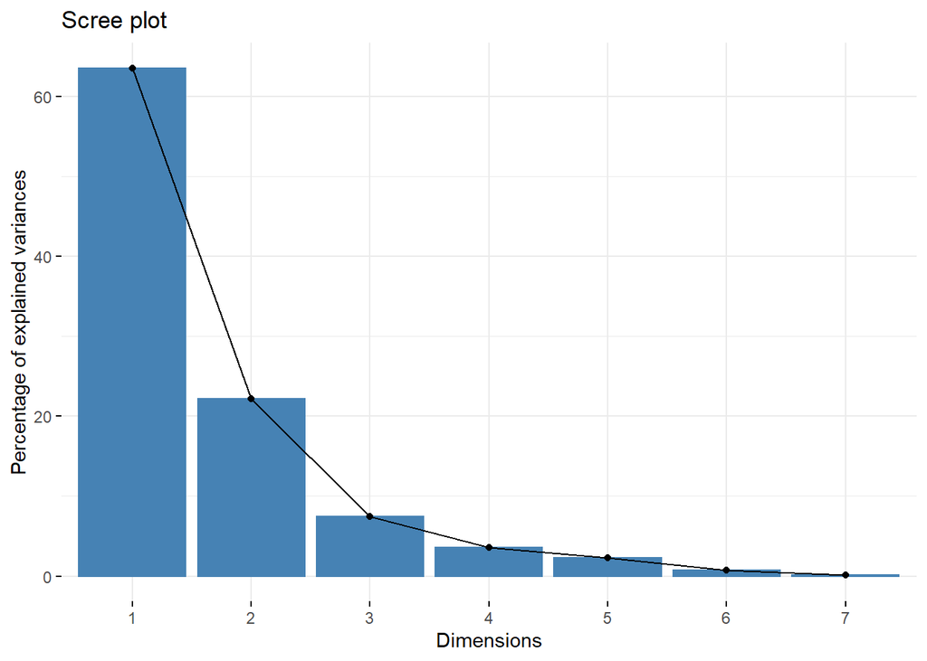

```r
fviz_eig(pizza_pca)
```

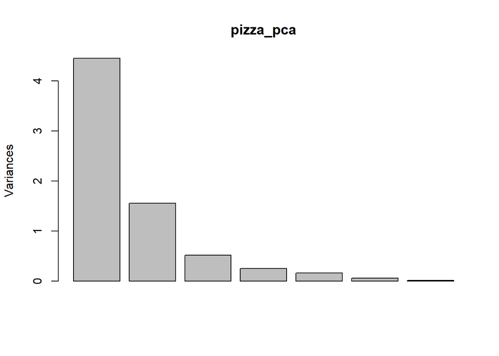

```r
screeplot(pizza_pca)
```

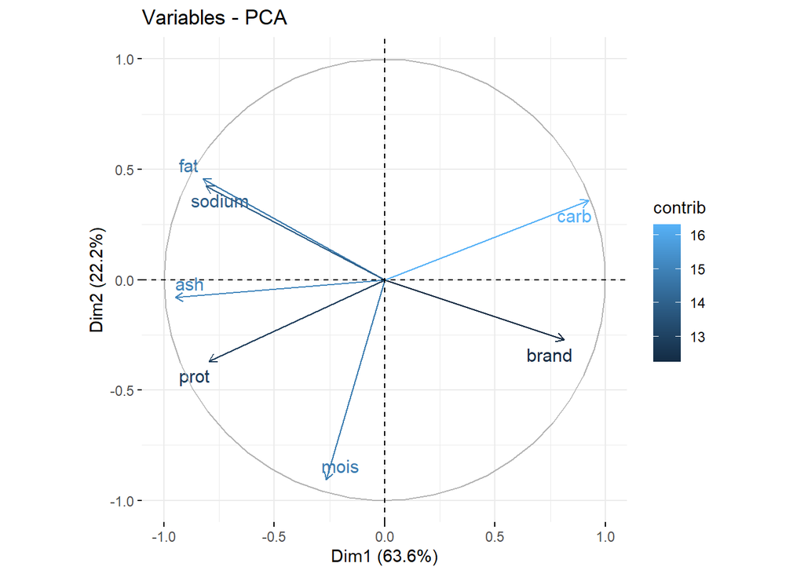

```r
fviz_pca_var(pizza_pca, col.var = "contrib", repel = TRUE)
```

```r
get_eigenvalue(pizza_pca)
```

```
##       eigenvalue variance.percent cumulative.variance.percent
## Dim.1 4.45029166       63.5755951                    63.57560
## Dim.2 1.55413177       22.2018825                    85.77748
## Dim.3 0.51963015        7.4232879                    93.20077
## Dim.4 0.25015149        3.5735926                    96.77436
## Dim.5 0.16174725        2.3106751                    99.08503
## Dim.6 0.05330395        0.7614850                    99.84652
## Dim.7 0.01074373        0.1534819                   100.00000
```

```r
get_pca_var(pizza_pca)
```

```
## Principal Component Analysis Results for variables
##  ===================================================
##   Name       Description
## 1 "$coord"   "Coordinates for the variables"
## 2 "$cor"     "Correlations between variables and dimensions"
## 3 "$cos2"    "Cos2 for the variables"
## 4 "$contrib" "contributions of the variables"
```

Then, I performed the splitting of the data set in the ratio of 80:20 where 80% of the data represents the training set and the remaining 20% represents the validation set. The number of rows for the training set data is 240 and of validation set is 60. The reason for picking 80:20 split is that it is based on Pareto Principle which asserts that 80% of outcomes (or outputs) result from 20% of all causes (or inputs) for any given event. Also, as the data in the testing set already contains known values for the attribute that one wants to predict, it is easy to determine whether the model’s guesses are correct. Thus, the training data set is given 80% of the weightage.

```r
#splitting of the data set in the ratio of 80:20
set.seed(123)
train.size <- 0.8
train.index <- sample.int(nrow(pizza_df), round(nrow(pizza_df) * train.size))
records.train <- pizza_df[train.index,]
records.validation <- pizza_df[-train.index,]
nrow(records.train)
```

```
## [1] 240
```

```r
nrow(records.validation)
```

```
## [1] 60
```

```r
head(records.train)
```

```
##     brand       mois       prot       fat        ash    sodium       carb cal
## 179     7 0.10397269 0.05627907 0.2541063 0.05399061 0.1168831 0.96924995   0
## 14      1 0.18342644 0.58930233 0.9195652 0.85446009 0.9090909 0.04778724   0
## 195     7 0.08441962 0.05023256 0.2647343 0.04225352 0.1103896 0.97693746   0
## 118     4 0.67659839 0.63813953 0.5004831 0.79342723 0.2922078 0.04861833   0
## 229     8 0.34109249 0.05813953 0.2951691 0.05399061 0.1298701 0.77436111   0
## 244     9 0.86592179 0.14930233 0.2408213 0.19953052 0.1558442 0.41616455   1
```

```r
head(records.validation)
```

```
##    brand       mois      prot       fat       ash    sodium        carb cal
## 2      1 0.10831782 0.6641860 0.9543478 0.9788732 1.0000000 0.010596302   0
## 3      1 0.10397269 0.6051163 1.0000000 0.3361328 0.8961039 0.006025348   0
## 12     1 0.06145251 0.2891797 0.9818841 0.9342723 0.9220779 0.023478080   0
## 15     1 0.18342644 0.6413953 0.9094203 0.8755869 0.8831169 0.018283815   0
## 19     1 0.21104904 0.2891797 0.8710145 1.0000000 0.8831169 0.030542281   0
## 38     2 0.90254500 0.2930233 0.5041063 0.4530516 0.3571429 0.078537295   1
```

```r
#converting the numeric columns to factor
records.train$cal <- as.factor(records.train$cal)
records.validation$cal <- as.factor(records.validation$cal)
```

#MODEL 1: LOGISTIC REGRESSION MODEL

To evaluate the model, I am going to perform 10 fold cross-validation to have a better insight of my data and model. The train function () is going to be used further as this validation would turn the process 10 times. Here, a data set is reserved to should be used in the model for testing purposes. The values of the dependent variable are predicted and the accuracy of the model is calculated here. The advantage of this method is that in each repetition, the data sample is shuffled which leads to different splits of the sample data.

```r
#performing the 10 fold cross validation
control <- trainControl(method = "cv", number = 10)
```

```r
#Using glm method for logistic model
logistic_model <- suppressWarnings(train(cal ~ ., trControl = control, data = records.train, method = "glm"))
```

```r
summary(logistic_model)
```

```
##
## Call:
## NULL
##
## Deviance Residuals:
##        Min          1Q      Median          3Q         Max
## -4.297e-04  -2.000e-08  -2.000e-08   2.000e-08   4.888e-04
##
## Coefficients:
##              Estimate Std. Error z value Pr(>|z|)
## (Intercept)  -2600.73  357155.44  -0.007    0.994
## brand          -13.66   14176.97  -0.001    0.999
## mois          3340.59  270397.86   0.012    0.990
## prot           818.41  128779.44   0.006    0.995
## fat          -1945.00  275127.88  -0.007    0.994
## ash            647.21  182521.85   0.004    0.997
## sodium        -296.30  169876.27  -0.002    0.999
## carb          2032.92  383799.47   0.005    0.996
##
## (Dispersion parameter for binomial family taken to be 1)
##
##     Null deviance: 3.1755e+02  on 239  degrees of freedom
## Residual deviance: 7.2749e-07  on 232  degrees of freedom
## AIC: 16
##
## Number of Fisher Scoring iterations: 25
```

```r
#using predict
predict_logistic_model <- predict(logistic_model, newdata = records.validation)
predict_logistic_model
```

```
##  [1] 0 0 0 0 0 0 1 0 0 0 1 0 1 1 1 0 1 0 0 1 1 0 1 0 0 0 0 0 0 0 0 0 0 0 0 0 0 0
## [39] 0 0 0 0 0 0 0 0 0 1 1 1 1 1 1 1 1 1 1 1 0 1
## Levels: 0 1
```

```r
#Finding the accuracy, sensitivity, and specificity through confusion matrix
confusionMatrix(predict_logistic_model, records.validation$cal)
```

```
## Confusion Matrix and Statistics
##
##           Reference
## Prediction  0  1
##          0 37  2
##          1  0 21
##
##                Accuracy : 0.9667
##                  95% CI : (0.8847, 0.9959)
##     No Information Rate : 0.6167
##     P-Value [Acc > NIR] : 1.827e-10
##
##                   Kappa : 0.9283
##
##  Mcnemar's Test P-Value : 0.4795
##
##             Sensitivity : 1.0000
##             Specificity : 0.9130
##          Pos Pred Value : 0.9487
##          Neg Pred Value : 1.0000
##              Prevalence : 0.6167
##          Detection Rate : 0.6167
##    Detection Prevalence : 0.6500
##       Balanced Accuracy : 0.9565
##
##        'Positive' Class : 0
##
```

```r
# Accuracy, Sensitivity and Specificity
print("The accuracy of the classification using Logistic regression model is 96.67%")
```

```
## [1] "The accuracy of the classification using Logistic regression model is 96.67%"
```

```r
print("The Sensitivity of the model is 1")
```

```
## [1] "The Sensitivity of the model is 1"
```

```r
print("The Specificity of the model is .9130")
```

```
## [1] "The Specificity of the model is .9130"
```

Here, the accuracy score of logistic regression is 96.67 and balanced accuracy is 95.65. This model also has a sensitivity of 1 and specificity of .91

MODEL 2: RANDOM FOREST MODEL

```r
control <- trainControl(method = "cv", number = 10)
```

```r
#Using rf method for logistic model
rf_model <- suppressWarnings(train(cal ~ ., trControl = control, data = records.train, method = "rf"))
```

```r
print(rf_model)
```

```
## Random Forest
##
## 240 samples
##   7 predictor
##   2 classes: '0', '1'
##
## No pre-processing
## Resampling: Cross-Validated (10 fold)
## Summary of sample sizes: 216, 216, 216, 216, 216, 216, ...
## Resampling results across tuning parameters:
##
##   mtry  Accuracy   Kappa
##   2     0.9458333  0.8841821
##   4     0.9500000  0.8943852
##   7     0.9416667  0.8766074
##
## Accuracy was used to select the optimal model using the largest value.
## The final value used for the model was mtry = 4.
```

```r
#using predict
predict_rf_model <- predict(rf_model, newdata = records.validation)
predict_rf_model
```

```
##  [1] 0 0 0 0 0 1 1 0 0 0 1 0 1 1 1 1 1 1 0 1 1 0 1 0 0 0 0 0 0 0 0 0 0 0 0 0 0 0
## [39] 0 0 0 0 0 0 0 0 0 1 1 1 1 1 1 1 1 1 1 1 1 1
## Levels: 0 1
```

```r
#Finding the accuracy, sensitivity, and specificity through confusion matrix
confusionMatrix(predict_rf_model, records.validation$cal)
```

```
## Confusion Matrix and Statistics
##
##           Reference
## Prediction  0  1
##          0 34  1
##          1  3 22
##
##                Accuracy : 0.9333
##                  95% CI : (0.838, 0.9815)
##     No Information Rate : 0.6167
##     P-Value [Acc > NIR] : 2.068e-08
##
##                   Kappa : 0.8613
##
##  Mcnemar's Test P-Value : 0.6171
##
##             Sensitivity : 0.9189
##             Specificity : 0.9565
##          Pos Pred Value : 0.9714
##          Neg Pred Value : 0.8800
##              Prevalence : 0.6167
##          Detection Rate : 0.5667
##    Detection Prevalence : 0.5833
##       Balanced Accuracy : 0.9377
##
##        'Positive' Class : 0
##
```

```r
# Accuracy, Sensitivity and Specificity
print("The accuracy of the classification using Random forest model is 93.33%")
```

```
## [1] "The accuracy of the classification using Random forest model is 93.33%"
```

```r
print("The Sensitivity of the model is 0.9189")
```

```
## [1] "The Sensitivity of the model is 0.9189"
```

```r
print("The Specificity of the model is 0.9565")
```

```
## [1] "The Specificity of the model is 0.9565"
```

Here, random forest model has a lesser accuracy than the logistic regression model with an accuracy of 93.33 and a balanced accuracy of 93.77. But, it has the highest specificity among all the selected models.

#MODEL 3: KNN MODEL

```r
control <- trainControl(method = "cv", number = 10)
```

```r
#Using knn method for logistic model
knn_model <- suppressWarnings(train(cal ~ ., trControl = control, data = records.train, method = "knn"))
```

```r
print(knn_model)
```

```
## k-Nearest Neighbors
##
## 240 samples
##   7 predictor
##   2 classes: '0', '1'
##
## No pre-processing
## Resampling: Cross-Validated (10 fold)
## Summary of sample sizes: 216, 216, 216, 216, 216, 216, ...
## Resampling results across tuning parameters:
##
##   k  Accuracy   Kappa
##   5  0.9291667  0.8468836
##   7  0.9166667  0.8187690
##   9  0.9166667  0.8187690
##
## Accuracy was used to select the optimal model using the largest value.
## The final value used for the model was k = 5.
```

```r
#using predict
predict_knn_model <- predict(knn_model, newdata = records.validation)
predict_knn_model
```

```
##  [1] 0 0 0 0 0 0 1 0 0 0 1 1 1 1 1 1 1 1 1 1 1 0 1 0 0 0 0 0 0 0 0 0 0 0 0 0 0 0
## [39] 0 0 0 0 0 0 0 0 0 1 1 1 1 1 1 1 1 1 1 1 1 1
## Levels: 0 1
```

```r
#Finding the accuracy, sensitivity, and specificity through confusion matrix
confusionMatrix(predict_knn_model, records.validation$cal)
```

```
## Confusion Matrix and Statistics
##
##           Reference
## Prediction  0  1
##          0 32  2
##          1  5 21
##
##                Accuracy : 0.8833
##                  95% CI : (0.7743, 0.9518)
##     No Information Rate : 0.6167
##     P-Value [Acc > NIR] : 4.383e-06
##
##                   Kappa : 0.7592
##
##  Mcnemar's Test P-Value : 0.4497
##
##             Sensitivity : 0.8649
##             Specificity : 0.9130
##          Pos Pred Value : 0.9412
##          Neg Pred Value : 0.8077
##              Prevalence : 0.6167
##          Detection Rate : 0.5333
##    Detection Prevalence : 0.5667
##       Balanced Accuracy : 0.8890
##
##        'Positive' Class : 0
##
```

```r
# Accuracy, Sensitivity and Specificity
print("The accuracy of the classification using KNN model is 88.33%")
```

```
## [1] "The accuracy of the classification using KNN model is 88.33%"
```

```r
print("The Sensitivity of the model is 0.8649")
```

```
## [1] "The Sensitivity of the model is 0.8649"
```

```r
print("The Specificity of the model is 0.9130")
```

```
## [1] "The Specificity of the model is 0.9130"
```

The accuracy of the knn model is 88.33 and balanced accuracy is 88.90 which is the least among the three models.

MODEL 4: SVM MODEL

```r
set.seed(123)
library(e1071)
svm_model <- svm(cal ~., data = records.train, type = 'C-classification', kernel = 'linear')
svm_model
```

```
##
## Call:
## svm(formula = cal ~ ., data = records.train, type = "C-classification",
##     kernel = "linear")
##
##
## Parameters:
##    SVM-Type:  C-classification
##  SVM-Kernel:  linear
##        cost:  1
##
## Number of Support Vectors:  37
```

```r
#using predict
predict_svm_model <- predict(svm_model, records.validation)
predict_svm_model
```

```
##   2   3  12  15  19  38  44  47  49  56  62  65  68  80  82  92  96  97  99 100
##   0   0   0   0   0   0   1   0   0   0   1   1   1   1   1   1   1   1   1   1
## 103 117 119 120 124 132 138 146 148 150 162 167 169 176 177 183 186 187 196 208
##   1   0   1   0   0   0   0   0   0   0   0   0   0   0   0   0   0   0   0   0
## 212 214 219 227 231 236 239 242 245 246 248 265 267 268 270 278 279 281 295 300
##   0   0   0   0   0   0   0   1   1   1   1   1   1   1   1   1   1   1   1   1
## Levels: 0 1
```

```r
#Finding the accuracy, sensitivity, and specificity through confusion matrix
confusionMatrix(predict_svm_model, records.validation$cal)
```

```
## Confusion Matrix and Statistics
##
##           Reference
## Prediction  0  1
##          0 32  2
##          1  5 21
##
##                Accuracy : 0.8833
##                  95% CI : (0.7743, 0.9518)
##     No Information Rate : 0.6167
##     P-Value [Acc > NIR] : 4.383e-06
##
##                   Kappa : 0.7592
##
##  Mcnemar's Test P-Value : 0.4497
##
##             Sensitivity : 0.8649
##             Specificity : 0.9130
##          Pos Pred Value : 0.9412
##          Neg Pred Value : 0.8077
##              Prevalence : 0.6167
##          Detection Rate : 0.5333
##    Detection Prevalence : 0.5667
##       Balanced Accuracy : 0.8890
##
##        'Positive' Class : 0
##
```

```r
# Accuracy, Sensitivity and Specificity
print("The accuracy of the classification using SVM model is 88.33%")
```

```
## [1] "The accuracy of the classification using SVM model is 88.33%"
```

```r
print("The Sensitivity of the model is 0.8649")
```

```
## [1] "The Sensitivity of the model is 0.8649"
```

```r
print("The Specificity of the model is 0.9130")
```

```
## [1] "The Specificity of the model is 0.9130"
```

The accuracy of the SVM model is 88.33 and balanced accuracy is 88.90 which is same as the KNN model.

```r
#Comparing algorithms
results <- resamples(list(Logistic_Model=logistic_model, RandomForest_Model=rf_model,KNN_Model=knn_model))
summary(results)
```

```
##
## Call:
## summary.resamples(object = results)
##
## Models: Logistic_Model, RandomForest_Model, KNN_Model
## Number of resamples: 10
##
## Accuracy
##                         Min.   1st Qu.    Median      Mean   3rd Qu. Max. NA's
## Logistic_Model     0.9166667 0.9583333 1.0000000 0.9750000 1.0000000    1    0
## RandomForest_Model 0.8750000 0.9166667 0.9583333 0.9500000 1.0000000    1    0
## KNN_Model          0.8333333 0.9166667 0.9166667 0.9291667 0.9583333    1    0
##
## Kappa
##                         Min.   1st Qu.    Median      Mean   3rd Qu. Max. NA's
## Logistic_Model     0.8222222 0.9100791 1.0000000 0.9474144 1.0000000    1    0
## RandomForest_Model 0.7272727 0.8222222 0.9110672 0.8943852 1.0000000    1    0
## KNN_Model          0.6279070 0.8160207 0.8297872 0.8468836 0.9090909    1    0
```

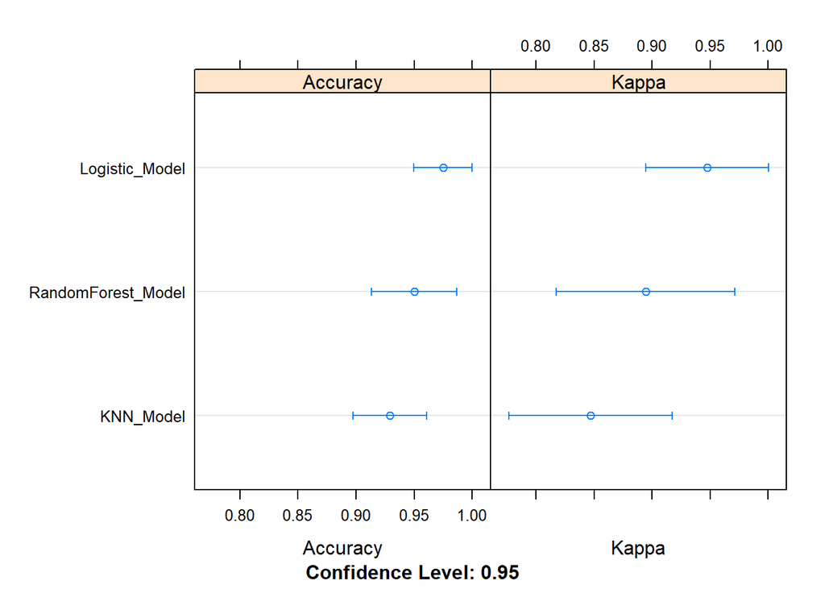

```r
dotplot(results)
```

```r
#Hyperparameters tuning for Random forest Model
hyperparameter_rf <- trainControl(method = "repeatedcv", number = 3, repeats = 5)
summary(hyperparameter_rf)
```

[output not shown]

```r
# hyperparameters tuning for Random Forest
rf_hyper <- train(cal ~ ., data = records.train, method = "rf", trControl = hyperparameter_rf, verbose = FALSE)
summary(rf_hyper)
```

```
##                 Length Class      Mode
## call               5   -none-     call
## type               1   -none-     character
## predicted        240   factor     numeric
## err.rate        1500   -none-     numeric
## confusion          6   -none-     numeric
## votes            480   matrix     numeric
## oob.times        240   -none-     numeric
## classes            2   -none-     character
## importance         7   -none-     numeric
## importanceSD       0   -none-     NULL
## localImportance    0   -none-     NULL
## proximity          0   -none-     NULL
## ntree              1   -none-     numeric
## mtry               1   -none-     numeric
## forest            14   -none-     list
## y                240   factor     numeric
## test               0   -none-     NULL
## inbag              0   -none-     NULL
## xNames             7   -none-     character
## problemType        1   -none-     character
## tuneValue          1   data.frame list
## obsLevels          2   -none-     character
## param              1   -none-     list
```

```r
# hyperparameters tuning for SVM
hyperparameter_svm <- trainControl(method = "repeatedcv", number = 3, repeats = 5)
summary(hyperparameter_svm)
```

[output not shown]

```r
#Hyperparameters tuning for SVM Model
svm_hyper <- train(cal ~ ., data = records.train, method = "svmPoly", trControl = hyperparameter_svm, verbose = FALSE)
summary(svm_hyper)
```

```
## Length  Class   Mode
##      1   ksvm     S4
```

MODEL COMPARISONS

```r
#Logistic Regression model
logistic_table <- table(predict_logistic_model, records.validation$cal)
logistic_prec = as.data.frame(diag(logistic_table) / colSums(logistic_table))[1,]
logistic_recall = as.data.frame(diag(logistic_table) / rowSums(logistic_table))[1,]
logistic_recall
```

```
## [1] 0.9487179
```

```r
#Random Forest model
forest_table <- table(predict_rf_model, records.validation$cal)
forest_prec = as.data.frame(diag(forest_table) / colSums(forest_table))[1,]
forest_recall = as.data.frame(diag(forest_table) / rowSums(forest_table))[1,]
forest_recall
```

```
## [1] 0.9714286
```

```r
#KNN model
knn_table <- table(predict_knn_model, records.validation$cal)
knn_prec = as.data.frame(diag(knn_table) / colSums(knn_table))[1,]
knn_recall = as.data.frame(diag(knn_table) / rowSums(knn_table))[1,]
knn_recall
```

```
## [1] 0.9411765
```

```r
#SVM model
svm_table <- table(predict_svm_model, records.validation$cal)
svm_prec = as.data.frame(diag(svm_table) / colSums(svm_table))[1,]
svm_recall = as.data.frame(diag(svm_table) / rowSums(svm_table))[1,]
svm_recall
```

```
## [1] 0.9411765
```

```r
#install.packages("h2o")
library(h2o)
# initialize the h2o
h2o.init()
```

```
##  Connection successful!
##
## R is connected to the H2O cluster:
##     H2O cluster uptime:         1 hours 26 minutes
##     H2O cluster timezone:       America/New_York
##     H2O data parsing timezone:  UTC
##     H2O cluster version:        3.34.0.3
##     H2O cluster version age:    2 months and 10 days
##     H2O cluster name:           H2O_started_from_R_raghv_cpz299
##     H2O cluster total nodes:    1
##     H2O cluster total memory:   2.28 GB
##     H2O cluster total cores:    8
##     H2O cluster allowed cores:  8
##     H2O cluster healthy:        TRUE
##     H2O Connection ip:          localhost
##     H2O Connection port:        54321
##     H2O Connection proxy:       NA
##     H2O Internal Security:      FALSE
##     H2O API Extensions:         Amazon S3, Algos, AutoML, Core V3, TargetEncoder, Core V4
##     R Version:                  R version 4.0.5 (2021-03-31)
```

```r
#Creating the training and test h2o data frames
train_df_h2o<-as.h2o(records.train)
test_df_h2o<-as.h2o(records.validation)
#Identify predictors and response
y <- "cal"
x <- setdiff(names(train_df_h2o), y)

# Number of CV folds
nfolds <- 5

#Generating a 2-model ensemble (GLM + RF)

#Training & Cross-validating the GBM
my_logistic <- h2o.glm(x = x,
                  y = y,
                  training_frame = train_df_h2o,
                  nfolds = nfolds,
                  keep_cross_validation_predictions = TRUE,
                  seed = 5)
# Training & cross-validating the RF
my_rf <- h2o.randomForest(x = x,
                          y = y,
                          training_frame = train_df_h2o,
                          nfolds = nfolds,
                          keep_cross_validation_predictions = TRUE,
                          seed = 5)
# Training a stacked random forest ensemble using the GBM and RF
ensemble <- h2o.stackedEnsemble(x = x,
                                y = y,
                                metalearner_algorithm="drf",
                                training_frame = train_df_h2o,
                                base_models = list(my_logistic, my_rf))
#Ensemble performance on a test set
perf <- h2o.performance(ensemble, newdata = test_df_h2o)
```

```r
#Comparing to base learner performance on the test set
perf_logistic_test <- h2o.performance(my_logistic, newdata = test_df_h2o)
perf_rf_test <- h2o.performance(my_rf, newdata = test_df_h2o)
```

```r
perf_logistic_test
```

```
## H2OBinomialMetrics: glm
##
## MSE:  0.04288049
## RMSE:  0.207076
## LogLoss:  0.1226329
## Mean Per-Class Error:  0.04347826
## AUC:  0.9894242
## AUCPR:  0.985273
## Gini:  0.9788484
## R^2:  0.8186019
## Residual Deviance:  14.71594
## AIC:  30.71594
##
## Confusion Matrix (vertical: actual; across: predicted) for F1-optimal threshold:
##         0  1    Error   Rate
## 0      37  0 0.000000  =0/37
## 1       2 21 0.086957  =2/23
## Totals 39 21 0.033333  =2/60
##
## Maximum Metrics: Maximum metrics at their respective thresholds
##                         metric threshold     value idx
## 1                       max f1  0.865748  0.954545  20
## 2                       max f2  0.190704  0.958333  27
## 3                 max f0point5  0.865748  0.981308  20
## 4                 max accuracy  0.865748  0.966667  20
## 5                max precision  1.000000  1.000000   0
## 6                   max recall  0.190704  1.000000  27
## 7              max specificity  1.000000  1.000000   0
## 8             max absolute_mcc  0.865748  0.930710  20
## 9   max min_per_class_accuracy  0.865748  0.913043  20
## 10 max mean_per_class_accuracy  0.865748  0.956522  20
## 11                     max tns  1.000000 37.000000   0
## 12                     max fns  1.000000 22.000000   0
## 13                     max fps  0.000000 37.000000  58
## 14                     max tps  0.190704 23.000000  27
## 15                     max tnr  1.000000  1.000000   0
## 16                     max fnr  1.000000  0.956522   0
## 17                     max fpr  0.000000  1.000000  58
## 18                     max tpr  0.190704  1.000000  27
##
## Gains/Lift Table: Extract with `h2o.gainsLift(<model>, <data>)` or `h2o.gainsLift(<model>, valid=<T/F>, xval=<T/F>)`
```

```r
perf_rf_test
```

```
## H2OBinomialMetrics: drf
##
## MSE:  0.05814557
## RMSE:  0.2411339
## LogLoss:  0.1684896
## Mean Per-Class Error:  0.06521739
## AUC:  0.9841363
## AUCPR:  0.9777096
## Gini:  0.9682726
## R^2:  0.7540258
##
## Confusion Matrix (vertical: actual; across: predicted) for F1-optimal threshold:
##         0  1    Error   Rate
## 0      37  0 0.000000  =0/37
## 1       3 20 0.130435  =3/23
## Totals 40 20 0.050000  =3/60
##
## Maximum Metrics: Maximum metrics at their respective thresholds
##                         metric threshold     value idx
## 1                       max f1  0.790000  0.930233   8
## 2                       max f2  0.120000  0.950413  16
## 3                 max f0point5  0.790000  0.970874   8
## 4                 max accuracy  0.790000  0.950000   8
## 5                max precision  1.000000  1.000000   0
## 6                   max recall  0.120000  1.000000  16
## 7              max specificity  1.000000  1.000000   0
## 8             max absolute_mcc  0.790000  0.896854   8
## 9   max min_per_class_accuracy  0.639167  0.913043  12
## 10 max mean_per_class_accuracy  0.790000  0.934783   8
## 11                     max tns  1.000000 37.000000   0
## 12                     max fns  1.000000 21.000000   0
## 13                     max fps  0.000000 37.000000  21
## 14                     max tps  0.120000 23.000000  16
## 15                     max tnr  1.000000  1.000000   0
## 16                     max fnr  1.000000  0.913043   0
## 17                     max fpr  0.000000  1.000000  21
## 18                     max tpr  0.120000  1.000000  16
##
## Gains/Lift Table: Extract with `h2o.gainsLift(<model>, <data>)` or `h2o.gainsLift(<model>, valid=<T/F>, xval=<T/F>)`
```

To conclude, among all the models that I have selected in this project, the model that I prefer the most is the logistic regression model as it has the maximum accuracy and sensitivity among all the four models used here.

THANK YOU